# 1. Les branches

- Les branches sont comme des “Sauvegarder sous…” pour l’ensemble du dépôt
  - Sauf qu’on peut les joindre/fusionner plus facilement !
- La branche par défaut s’appelle master (ou main)
- Les branches offrent la possibilité de travailler sur différents problèmes en parallèle :
  - Une branche principale master
  - Une branche bug 1
  - Une branche bug 2 parce que celui-ci est plus pressé
  - etc…

# 2. Les branches : vocabulaire et commandes

- **Créer une branche** : `git branch [nom de la branche]`
- **Se déplacer dans une branche** : `git checkout [nom de la branche]`
- **Créer et se déplacer sur une nouvelle branche en même temps** : `git checkout -b [nom de la branche]`
- **Fusionner une branche** : `git merge [branche dont on veut les modifications]` (on fusionne toujours depuis la branche réceptrice, celle sur laquelle on veut continuer de travailler ensuite)

## Exercices :

Tout au long de ces exercices, vérifier et observer les résultats des commandes git status, git log et git diff (le cas échéant). - Créer un dossier exercice_cours2 - Initialiser ce dossier en dépôt Git - Enregistrer un premier fichier master.md - Créer une branche cheat_sheet dans laquelle sera enregistré le fichier https://training.github.com/downloads/fr/github-git-cheat-sheet.pdf

- Créer une branche dev dans laquelle sera créé un fichier texte cours2.md contenant l’URL ci-dessus
- Modifier ce fichier cours2.md en remplaçant l’URL par un texte de votre choix
- Enregistrer ce changement
- De retour sur la branche principale (master ou main) :
- Fusionner la branche dev pour intégrer cours2.md à la branche principale
- Annuler la fusion (tip : git reset [n° commit] –hard)

Des corrections pas à pas sont disponibles dans les [notes de ce cours](https://github.com/vicpsl/cours-git/blob/master/cours-2/notes.md).

# 3. Branches

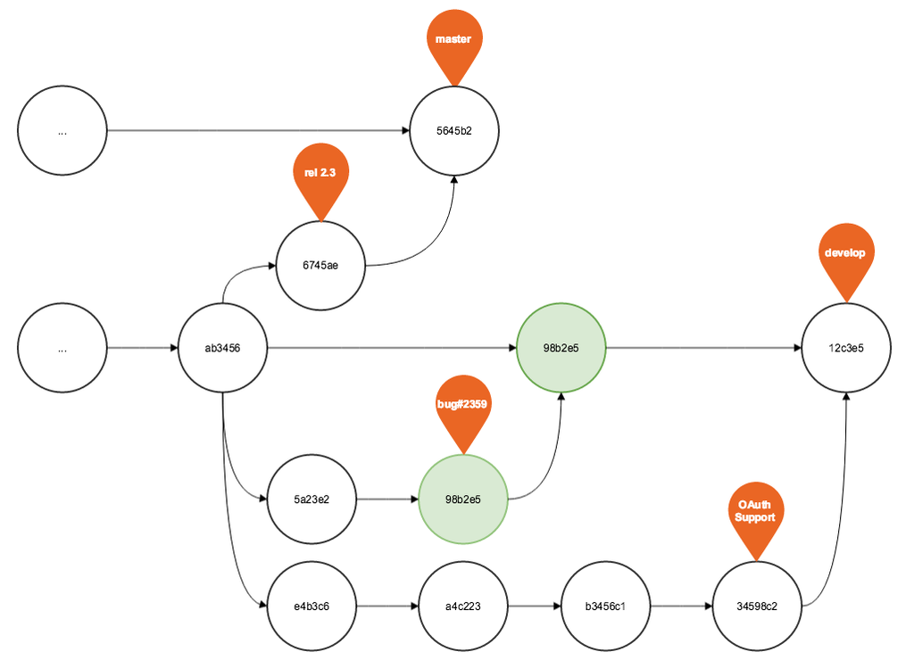

# 4. Conflits d’historique

1. Copier le fichier xml https://raw.githubusercontent.com/vicpsl/cours-git/master/cours-2/exemple.xml
2. Enregistrer ce changement dans git
3. Changer de branche pour `changement_texte`
4. Remplir Titre et Auteur avec le titre de votre livre préféré et auteur préféré
5. Enregistrer ce changement dans git

# 5. Conflits d’historique : le professeur change d’avis

1. Changer de branche pour `master`
2. Changer le titre et l’auteur pour “Epigrammes” et “Martial”
3. Enregistrer le changement de cette branche `master`
4. Fusionner la branche changement_texte  
   Alors ?
5. Résolution d’un conflit (simple) :
   1. Ouvrir le fichier (exemple.xml)

   ```
   <TEI xmlns="http://www.tei-c.org/ns/1.0">
                 <teiHeader>
                     <fileDesc>
                        <titleStmt>
               <<<<<<< HEAD
                           <title>Epigrammes</title>
                           <author>Martial</title>
               =======
                           <title>Tom</title>
                           <author>Riddle</title>
               >>>>>>> changement_texte
                        </titleStmt>
               ...
   ```

   Comme vous pouvez le voir, Git a ajouté une syntaxe comprenant sept caractères “inférieurs à” (<<<<<<<) et sept caractères “supérieurs à” (>>>>>>>), séparés par sept signes égal, =======.  
   Ceux-ci peuvent être recherchés à l’aide de votre éditeur pour trouver rapidement où les modifications doivent être apportées.  
   Il y a deux sections dans ce bloc :
- Les caractères <<<<<<< indiquent les modifications de la branche actuelle (dans ce cas, “HEAD”, qui est un autre mot pour votre branche actuelle, dans notre cas “master”), et les signes ======= indiquent la fin de la première section.
- La deuxième section est celle où les modifications proviennent de la tentative de fusion, ici “changement_texte”: il commence après les signes égal et se termine par les signes >>>>>>>.
  2. Editer le fichier en ne conservant que le contenu final souhaité, par exemple :

  ```
  <TEI xmlns="http://www.tei-c.org/ns/1.0">
                <teiHeader>
                    <fileDesc>
                       <titleStmt>
                          <title>Tom</title>
                          <author>Riddle</title>
                       </titleStmt>
              ...
  ```

  3. Enregistrer le changement (git add exemple.xml puis git commit -m “résolution du conflit fichier TEI”)
  4. Vérifier le résultat

Des corrections pas à pas sont disponibles dans les [notes de ce cours](https://github.com/vicpsl/cours-git/blob/master/cours-2/notes.md).